# Lab Five: Wide and Deep Networks

### Member : Yang Shen

## Introduction

Washington, D.C. is the capital of the United States. Washington's population is approaching 700,000 people, and has been growing since 2000 following a half-century of population decline. This dataset contain the posted properties sale information from 2010 to 2018. There are totla 152779 number of records. The null price means that the property has not been sold. I am interested the price of sold properties. I change the price from numeric variable to binary variable. The sell price below 400,000 is normal price and above is high price.

- ID - Unique number for each athlete each event
- BATHRM - Number of full bathrooms
- HEAT_D – heat type
- AC - Y is have AC, N is not
- BEDRM - Number if bed room
- AYB - The earliest time the main portion of the building was built.
- AYB_year - The number of year of earliest time the main portion of the building was built until now
- YR_RMDL - Last year residence was remodeled
- YR_RMDL_year - The number of year until now of last time residence was remodeled
- EYB - The year that an improvement was built that is most often more recent than actual year built.
- EYB_year - The number of year until now of improvement was built
- STORAGE – Number of storage
- PRICE - selling price
- QUALIFIED – Qualified value of 'U' suggests sale is not reflective of market value
- GBA - Gross building area in square feet
- STRUCT_D – Structure description
- CNDTN_D – Condition description
- ROOF_D – Roff discription
- INTWALL_D – Interior wall description
- KITCHENS – Number of kitchens

```python
#https://www.kaggle.com/christophercorrea/dc-residential-properties#raw_residential_data.csv
# load the dataset
import pandas as pd
import numpy as np
import warnings
warnings.filterwarnings('ignore')

print('Pandas:', pd.__version__)
print('Numpy:',np.__version__)

dfraw = pd.read_csv('https://raw.githubusercontent.com/sy0701611/lab-3/master/raw_residential_data.csv',error_bad_lines=False)
# read in the csv file,offending lines to be skipped

dfraw.info()
```

```
Pandas: 0.24.2
Numpy: 1.16.2
<class 'pandas.core.frame.DataFrame'>
RangeIndex: 152779 entries, 0 to 152778
Data columns (total 20 columns):
ID              152779 non-null int64
BATHRM          152745 non-null float64
HEAT_D          152745 non-null object
AC              152745 non-null object
BEDRM           152739 non-null float64
AYB             152764 non-null float64
AYB_year        152779 non-null int64
YR_RMDL_year    78419 non-null float64
YR_RMDL         78419 non-null float64
EYB_year        152779 non-null int64
EYB             152779 non-null int64
STORAGE         152669 non-null float64
PRICE           84985 non-null float64
QUALIFIED       152779 non-null object
GBA             152779 non-null int64
STRUCT_D        152745 non-null object
CNDTN_D         152745 non-null object
ROOF_D          152745 non-null object
INTWALL_D       152736 non-null object
KITCHENS        152744 non-null float64
dtypes: float64(8), int64(5), object(7)
memory usage: 23.3+ MB
```

```python
# find the duplicate
#no duplicate
idx = dfraw.duplicated()
len(dfraw[idx])
```

```
0
```

```python
#drop na becasue I am interested about the sold property
dfraw.dropna(inplace=True)#drop all na value beacsue row with na is not useful
df = dfraw[['BATHRM','HEAT_D','AC','BEDRM','AYB_year','YR_RMDL_year','EYB_year','STORAGE'
            ,'QUALIFIED','GBA','STRUCT_D','CNDTN_D','ROOF_D','INTWALL_D','KITCHENS','PRICE']]
```

I drop AYB,YR_RMDL,EYB because those are the year, I have variable which will reflect the number of year from their year until now. Which is more meaningful than just the year data. Drop ID becasue ID is not useful.

```python
df.PRICE = (df.PRICE>400000).astype(np.int)
df.PRICE.replace(to_replace=[0,1],value=['normal','high'],inplace=True)
df.info()
```

```
<class 'pandas.core.frame.DataFrame'>
Int64Index: 52986 entries, 0 to 152774
Data columns (total 16 columns):
BATHRM          52986 non-null float64
HEAT_D          52986 non-null object
AC              52986 non-null object
BEDRM           52986 non-null float64
AYB_year        52986 non-null int64
YR_RMDL_year    52986 non-null float64
EYB_year        52986 non-null int64
STORAGE         52986 non-null float64
QUALIFIED       52986 non-null object
GBA             52986 non-null int64
STRUCT_D        52986 non-null object
CNDTN_D         52986 non-null object
ROOF_D          52986 non-null object
INTWALL_D       52986 non-null object
KITCHENS        52986 non-null float64
PRICE           52986 non-null object
dtypes: float64(5), int64(3), object(8)
memory usage: 6.9+ MB
```

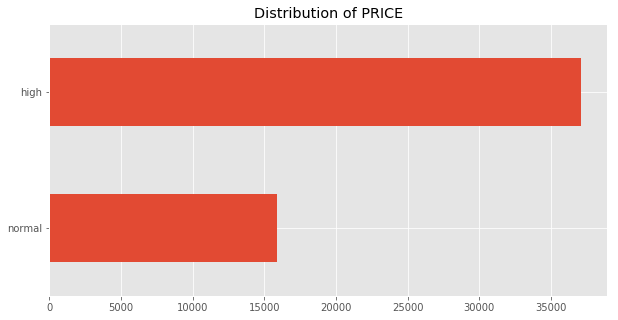

```python
plt.style.use('ggplot')

plt.figure(figsize=(10,5))
df['PRICE'].value_counts(sort=True,ascending=True).plot(kind='barh')
plt.title('Distribution of PRICE')

plt.show()
```

I change the price from numeric variable to binary variable. The sell price below 400,000 is normal price and above is high price.

# Dividing training and testing

```python
from sklearn.model_selection import train_test_split
df_train_orig, df_test_orig = train_test_split(df, test_size=0.2)
X = df.drop("PRICE", axis=1).as_matrix()
y = df["PRICE"].as_matrix()
```

```python
from copy import deepcopy
df_train = deepcopy(df_train_orig)
df_test = deepcopy(df_test_orig)
```

```python
import numpy as np

# let's just get rid of rows with any missing data
# and then reset the indices of the dataframe so it corresponds to row number
df_train.replace(to_replace=' ?',value=np.nan, inplace=True)
df_train.dropna(inplace=True)
df_train.reset_index()

df_test.replace(to_replace=' ?',value=np.nan, inplace=True)
df_test.dropna(inplace=True)
df_test.reset_index()

df_test.head()
```

|  | BATHRM | HEAT_D | AC | BEDRM | AYB_year | YR_RMDL_year | EYB_year | STORAGE | QUALIFIED | GBA | STRUCT_D | CNDTN_D | ROOF_D | INTWALL_D | KITCHENS | PRICE |
| --- | --- | --- | --- | --- | --- | --- | --- | --- | --- | --- | --- | --- | --- | --- | --- | --- |
| 113826 | 3.0 | Forced Air | Y | 4.0 | 119 | 3.0 | 33 | 2.0 | Q | 1670 | Row Inside | Good | Metal- Sms | Hardwood | 2.0 | high |
| 44045 | 3.0 | Forced Air | Y | 4.0 | 97 | 6.0 | 37 | 2.0 | Q | 1848 | Row Inside | Good | Built Up | Hardwood | 1.0 | high |
| 20173 | 1.0 | Hot Water Rad | Y | 3.0 | 107 | 4.0 | 52 | 2.0 | U | 1176 | Row End | Average | Metal- Sms | Hardwood | 1.0 | normal |
| 9217 | 2.0 | Forced Air | Y | 4.0 | 119 | 47.0 | 50 | 2.0 | Q | 1134 | Row Inside | Average | Metal- Sms | Hardwood | 2.0 | high |
| 133159 | 1.0 | Forced Air | Y | 3.0 | 109 | 34.0 | 62 | 2.0 | Q | 1028 | Row Inside | Average | Built Up | Wood Floor | 1.0 | normal |

I splite my data into training and testing set by 80/20, I did not use any k-fold becasue I have 52000 rows in my dataset after drop the na value, I think 52000 is enough to represent the features of dataset. However, in my comparision of model, I used 5 fold StratifiedKFold, because I need to use cross validation method and also I want my price normal and high have the same ratio in each fold. I used both 80/20 and StratifiedKFold as I need.

```python
from sklearn.preprocessing import LabelEncoder
from sklearn.preprocessing import StandardScaler

#replace strings
#if df_test.PRICE.dtype=='object':
#    df_test.PRICE.replace(to_replace=['0','1'],value=['normal','high'],inplace=True)
#    print(df_test.income.value_counts())

# define objects that can encode each variable as integer
encoders = dict()
categorical_headers = ['HEAT_D','AC','QUALIFIED','STRUCT_D','CNDTN_D','ROOF_D','INTWALL_D']

# train all encoders (special case the target 'PRICE')
for col in categorical_headers+['PRICE']:
    df_train[col] = df_train[col].str.strip()
    df_test[col] = df_test[col].str.strip()

    if col=="PRICE":
        tmp = LabelEncoder()
        df_train[col] = tmp.fit_transform(df_train[col])
        df_test[col] = tmp.transform(df_test[col])
    else:
        # integer encoded variables
        encoders[col] = LabelEncoder() # save the encoder
        df_train[col+'_int'] = encoders[col].fit_transform(df_train[col])
        df_test[col+'_int'] = encoders[col].transform(df_test[col])

# scale the numeric, continuous variables
numeric_headers = ["BATHRM","BEDRM","AYB_year","YR_RMDL_year","EYB_year","STORAGE"
            ,"GBA","KITCHENS"]

for col in numeric_headers:
    df_train[col] = df_train[col].astype(np.float)
    df_test[col] = df_test[col].astype(np.float)

    ss = StandardScaler()
    df_train[col] = ss.fit_transform(df_train[col].values.reshape(-1, 1))
    df_test[col] = ss.transform(df_test[col].values.reshape(-1, 1))

df_train.head()
```

|  | BATHRM | HEAT_D | AC | BEDRM | AYB_year | YR_RMDL_year | EYB_year | STORAGE | QUALIFIED | GBA | ... | INTWALL_D | KITCHENS | PRICE | HEAT_D_int | AC_int | QUALIFIED_int | STRUCT_D_int | CNDTN_D_int | ROOF_D_int | INTWALL_D_int |
| --- | --- | --- | --- | --- | --- | --- | --- | --- | --- | --- | --- | --- | --- | --- | --- | --- | --- | --- | --- | --- | --- |
| 32405 | -1.273703 | Forced Air | Y | -0.359388 | -0.311925 | -0.028223 | 0.614581 | -0.023048 | Q | -0.093861 | ... | Hardwood | -0.488369 | 0 | 5 | 2 | 0 | 4 | 4 | 11 | 3 |
| 143276 | -0.305399 | Forced Air | Y | -0.359388 | -0.134518 | -0.239958 | 1.195303 | -0.023048 | U | -0.598178 | ... | Hardwood | -0.488369 | 1 | 5 | 2 | 1 | 4 | 0 | 7 | 3 |
| 34935 | 1.631208 | Forced Air | Y | -0.359388 | -0.543919 | -0.187024 | -0.353288 | -0.023048 | Q | 1.208959 | ... | Hardwood | -0.488369 | 0 | 5 | 2 | 0 | 5 | 4 | 2 | 3 |
| 141575 | -0.305399 | Warm Cool | Y | -0.359388 | 0.097475 | -0.398759 | 0.033860 | -0.023048 | Q | -0.130943 | ... | Hardwood | -0.488369 | 0 | 12 | 2 | 0 | 2 | 4 | 7 | 3 |
| 102427 | -0.305399 | Warm Cool | Y | -0.359388 | -0.407452 | -0.663428 | 1.582451 | -0.023048 | U | -0.736618 | ... | Hardwood | -0.488369 | 1 | 12 | 2 | 1 | 2 | 4 | 0 | 3 |

5 rows × 23 columns

# Normalized

I used standard scalar to normalized my numeric variables. The idea behind StandardScaler is that it will transform my data such that its distribution will have a mean value 0 and standard deviation of 1. So that all numeric values are in same scales. no more really big data or really small data.

```python
# let's start as simply as possible, without any feature preprocessing
categorical_headers_ints = [x+'_int' for x in categorical_headers]

# we will forego one-hot encoding right now and instead just scale all inputs
#   this is just to get an example running in Keras (don't ever do this)
feature_columns = categorical_headers_ints+numeric_headers
X_train =  ss.fit_transform(df_train[feature_columns].values).astype(np.float32)
X_test =  ss.transform(df_test[feature_columns].values).astype(np.float32)

y_train = df_train['PRICE'].values.astype(np.int)
y_test = df_test['PRICE'].values.astype(np.int)

print(feature_columns)
```

```
['HEAT_D_int', 'AC_int', 'QUALIFIED_int', 'STRUCT_D_int', 'CNDTN_D_int', 'ROOF_D_int', 'INTWALL_D_int', 'BATHRM', 'BEDRM', 'AYB_year', 'YR_RMDL_year', 'EYB_year', 'STORAGE', 'GBA', 'KITCHENS']
```

```python
from sklearn import metrics as mt
import keras

keras.__version__
```

```
'2.2.4'
```

```python
# from keras.models import Sequential
from keras.layers import Dense, Activation, Input
from keras.layers import Embedding, Flatten, Concatenate
from keras.models import Model
import warnings
warnings.filterwarnings('ignore')
```

# Metrics

For my dataset, I have two metrics which is accuracy and FN score. I used accuracy because accuracy will directly reflect how well my prediction is. I want my model have high true positive rate and high true negative rate. Which means my model can predict the price well.

Another metric I am using here is customized FN score. It is calculated by FN/(FN+FP). For my case, if it predict false positive, that is ok because if we set low price house to a high price. The consequance is that nobody buy it. It just wasted of time, but no real money loss. However, false negative is we set high price house to low price to sell. That will cause seller loss money. They will not sell as their house should be. So that we want the false negative rate as low as possible. My FN score will reflect the ratio of false negative and all false prediction.

```python
#This is my own metric which is the FN/(FN+FP)
def custom_score(y_true, y_predict):
    cm = mt.confusion_matrix(y_test,yhat)
    FN = cm[1,0]/(cm[0,1]+cm[1,0])

    return FN
```

# Cross-product features

HEAT_D and AC: for the most house, they have both ac and heat, I combined these two because heat and AC is really important for house. They are similar, both of them can control temperature.

QUALIFIED and CNDTN_D: I think condition of house will reflect the qualified. Some house have good condition, so they sell reflect market value. I think those two are related.

ROOF_D and INTWALL_D: I think the material of roof and wall are related really closed. For example, I hot place, roof is usually reflect hear and wall is isolated heat from outside. Those materials are paired to perform the same function.

HEAT_D and INTWALL_D: For some hot area, they do not have heat or it is combine with AC, the wall meterial is also have same function to control the temperature as heat.

AC and ROOF_D: Same story as heat and wall, roof can reflect heat from sun. It have same function as AC, which is make house cool, So I think those two are meaningful to cross.

ROOF_D , INTWALL_D and STRUCT_D: Those are meterial for house to build, I think cross product them are meaningful. It will reflect the house construction.

# Model

## Model1 with 3 layer in Deep and cross combo1

```python
#model1
from keras.layers import concatenate
from sklearn.preprocessing import OneHotEncoder


#'HEAT_D','AC','QUALIFIED','STRUCT_D','CNDTN_D','ROOF_D','INTWALL_D'
#"BATHRM","BEDRM","AYB_year","YR_RMDL_year","EYB_year","STORAGE","GBA","KITCHENS"
cross_columns1 = [['HEAT_D','AC'],
                 ['QUALIFIED', 'CNDTN_D'],
                 ['ROOF_D','INTWALL_D']]

# and save off the numeric features
X_train_num =  df_train[numeric_headers].values
X_test_num = df_test[numeric_headers].values
#def create_model this just add in frount of original Dr. Larson code, doing this for cross validation
#https://github.com/Thakugan/machine-learning-notebooks/blob/master/6-wide-and-deep-networks/mushroom-hunting.ipynb
def create_model(X_train, X_test, X_train_num, categorical_headers_ints, cross_columns=cross_columns1):
    #this line is the only different campare to Dr. Larson code, this def is used for cross validation for loop
    embed_branches = []
    X_ints_train = []
    X_ints_test = []
    all_inputs = []
    all_wide_branch_outputs = []

    for cols in cross_columns:
    # encode crossed columns as ints for the embedding
        enc = LabelEncoder()

    # create crossed labels
        X_crossed_train = df_train[cols].apply(lambda x: '_'.join(x), axis=1)
        X_crossed_test = df_test[cols].apply(lambda x: '_'.join(x), axis=1)

        enc.fit(np.hstack((X_crossed_train.values,  X_crossed_test.values)))
        X_crossed_train = enc.transform(X_crossed_train)
        X_crossed_test = enc.transform(X_crossed_test)
        X_ints_train.append( X_crossed_train )
        X_ints_test.append( X_crossed_test )

    # get the number of categories
        N = max(X_ints_train[-1]+1) # same as the max(df_train[col])

    # create embedding branch from the number of categories
        inputs = Input(shape=(1,),dtype='int32', name = '_'.join(cols))
        all_inputs.append(inputs)
        x = Embedding(input_dim=N,
                  output_dim=int(np.sqrt(N)),
                  input_length=1, name = '_'.join(cols)+'_embed')(inputs)
        x = Flatten()(x)
        all_wide_branch_outputs.append(x)

# merge the branches together
    wide_branch = concatenate(all_wide_branch_outputs, name='wide_concat')
    wide_branch = Dense(units=1,activation='sigmoid',name='wide_combined')(wide_branch)

# reset this input branch
    all_deep_branch_outputs = []
# add in the embeddings
    for col in categorical_headers_ints:
    # encode as ints for the embedding
        X_ints_train.append( df_train[col].values )
        X_ints_test.append( df_test[col].values )

    # get the number of categories
        N = max(X_ints_train[-1]+1) # same as the max(df_train[col])

    # create embedding branch from the number of categories
        inputs = Input(shape=(1,),dtype='int32', name=col)
        all_inputs.append(inputs)
        x = Embedding(input_dim=N,
                  output_dim=int(np.sqrt(N)),
                  input_length=1, name=col+'_embed')(inputs)
        x = Flatten()(x)
        all_deep_branch_outputs.append(x)

# also get a dense branch of the numeric features
    all_inputs.append(Input(shape=(X_train_num.shape[1],),
                            sparse=False,
                            name='numeric_data'))

    x = Dense(units=20, activation='relu',name='numeric_1')(all_inputs[-1])
    all_deep_branch_outputs.append( x )

# merge the deep branches together
    deep_branch = concatenate(all_deep_branch_outputs,name='concat_embeds')
    deep_branch = Dense(units=50,activation='relu', name='deep1')(deep_branch)
    deep_branch = Dense(units=25,activation='relu', name='deep2')(deep_branch)
    deep_branch = Dense(units=10,activation='relu', name='deep3')(deep_branch)

    final_branch = concatenate([wide_branch, deep_branch],name='concat_deep_wide')
    final_branch = Dense(units=1,activation='sigmoid',name='combined')(final_branch)

    model = Model(inputs=all_inputs, outputs=final_branch)
    return model, X_ints_train, X_ints_test, X_train_num
```

```python
from IPython.display import SVG
from keras.utils.vis_utils import model_to_dot

# you will need to install pydot properly on your machine to get this running
SVG(model_to_dot(model).create(prog='dot', format='svg'))
```

[figure not shown]

```python
model.compile(optimizer='adagrad',
              loss='mean_squared_error',
              metrics=['accuracy'])
```

```python
# lets also add the history variable to see how we are doing
# and lets add a validation set to keep track of our progress
history = model.fit(X_ints_train+ [X_train_num],
                    y_train,
                    epochs=30,
                    batch_size=50,
                    verbose=1,
                    validation_data = (X_ints_test + [X_test_num], y_test))
```

```
Train on 42388 samples, validate on 10598 samples
```

```python
#accuracy score
yhat = np.round(model.predict(X_ints_test + [X_test_num]))
print(mt.confusion_matrix(y_test,yhat), 'Accuracy ',mt.accuracy_score(y_test,yhat))
#my FN score
print('FN score ',custom_score(y_test,yhat))
```

```
[[6646  731]
 [1139 2082]] Accuracy  0.8235516135119834
FN score  0.6090909090909091
```

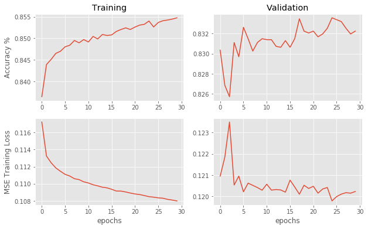

```python
from matplotlib import pyplot as plt

%matplotlib inline

plt.figure(figsize=(10,6))
plt.subplot(2,2,1)
plt.plot(history.history['acc'])

plt.ylabel('Accuracy %')
plt.title('Training')
plt.subplot(2,2,2)
plt.plot(history.history['val_acc'])
plt.title('Validation')

plt.subplot(2,2,3)
plt.plot(history.history['loss'])
plt.ylabel('MSE Training Loss')
plt.xlabel('epochs')

plt.subplot(2,2,4)
plt.plot(history.history['val_loss'])
plt.xlabel('epochs')
```

For train vs loss, I think it converge, the line reach the bottom. For validation, the line is boucing after 5 epochs, may be stop at 20 epochs is ok. But in general, they converge.

```python
#https://scikit-learn.org/stable/modules/generated/sklearn.model_selection.StratifiedKFold.html#sklearn.model_selection.StratifiedKFold.split
#https://github.com/Thakugan/machine-learning-notebooks/blob/master/6-wide-and-deep-networks/mushroom-hunting.ipynb
num_folds = 5

acc_scores =[]
fn_scores = []

skf = StratifiedKFold(n_splits=num_folds, shuffle=True)
for i, (train, test) in enumerate(skf.split(X, y)):#here I used corss validation on my model

    model, X_ints_train, X_ints_test, X_train_num = create_model(X_train, X_test, X_train_num, categorical_headers_ints, cross_columns1)
    #doing modeling same as above, without for loop
    model.compile(optimizer='adagrad',
                  loss='mean_squared_error',
                  metrics=['accuracy'])

    model.fit(X_ints_train + [X_train_num], y_train, epochs=30, batch_size=50, verbose=1)
#this is just what i do without cross validation
    yhat = np.round(model.predict(X_ints_test + [X_test_num]))
    print(mt.confusion_matrix(y_test,yhat))
    acc_score = mt.accuracy_score(y_test, yhat)
    acc_scores.append(acc_score)#append all acc for k-fold
    fn_score = custom_score(y_test,yhat)
    fn_scores.append(fn_score)#append all fn for k-fold
    print("Accuracy: ", acc_score)
    print("Fn : ", fn_score)
print(fn_scores)
print(acc_scores)
```

```
[[6584  793]
 [1102 2119]]
Accuracy:  0.8211926778637478
Fn :  0.5815303430079156
[[6650  727]
 [1115 2106]]
Accuracy:  0.8261936214380071
Fn :  0.6053203040173725
[[6589  788]
 [1068 2153]]
Accuracy:  0.8248726174749953
Fn :  0.5754310344827587
[[6644  733]
 [1176 2045]]
Accuracy:  0.819871673900736
Fn :  0.6160293347302253
[[6669  708]
 [1154 2067]]
Accuracy:  0.8243064729194187
Fn :  0.6197636949516648
[0.5815303430079156, 0.6053203040173725, 0.5754310344827587, 0.6160293347302253, 0.6197636949516648]
[0.8211926778637478, 0.8261936214380071, 0.8248726174749953, 0.819871673900736, 0.8243064729194187]
```

# Second model

## Model2 with 3 layer in Deep and cross combo2

```python
from keras.layers import concatenate
from sklearn.preprocessing import OneHotEncoder
#model2
#'HEAT_D','AC','QUALIFIED','STRUCT_D','CNDTN_D','ROOF_D','INTWALL_D'
#"BATHRM","BEDRM","AYB_year","YR_RMDL_year","EYB_year","STORAGE","GBA","KITCHENS"
cross_columns2 = [['HEAT_D','INTWALL_D'],
                 ['AC', 'ROOF_D'],
                 ['ROOF_D','INTWALL_D','STRUCT_D']]


# and save off the numeric features
X_train_num =  df_train[numeric_headers].values
X_test_num = df_test[numeric_headers].values

#this def model is prepare for the cross validation
def create_model1(X_train, X_test, X_train_num, categorical_headers_ints, cross_columns=cross_columns2):
    embed_branches = []
    X_ints_train = []
    X_ints_test = []
    all_inputs = []
    all_wide_branch_outputs = []

    for cols in cross_columns:
    # encode crossed columns as ints for the embedding
        enc = LabelEncoder()

    # create crossed labels
        X_crossed_train = df_train[cols].apply(lambda x: '_'.join(x), axis=1)
        X_crossed_test = df_test[cols].apply(lambda x: '_'.join(x), axis=1)

        enc.fit(np.hstack((X_crossed_train.values,  X_crossed_test.values)))
        X_crossed_train = enc.transform(X_crossed_train)
        X_crossed_test = enc.transform(X_crossed_test)
        X_ints_train.append( X_crossed_train )
        X_ints_test.append( X_crossed_test )

    # get the number of categories
        N = max(X_ints_train[-1]+1) # same as the max(df_train[col])

    # create embedding branch from the number of categories
        inputs = Input(shape=(1,),dtype='int32', name = '_'.join(cols))
        all_inputs.append(inputs)
        x = Embedding(input_dim=N,
                  output_dim=int(np.sqrt(N)),
                  input_length=1, name = '_'.join(cols)+'_embed')(inputs)
        x = Flatten()(x)
        all_wide_branch_outputs.append(x)

# merge the branches together
    wide_branch = concatenate(all_wide_branch_outputs, name='wide_concat')
    wide_branch = Dense(units=1,activation='sigmoid',name='wide_combined')(wide_branch)

# reset this input branch
    all_deep_branch_outputs = []
# add in the embeddings
    for col in categorical_headers_ints:
    # encode as ints for the embedding
        X_ints_train.append( df_train[col].values )
        X_ints_test.append( df_test[col].values )

    # get the number of categories
        N = max(X_ints_train[-1]+1) # same as the max(df_train[col])

    # create embedding branch from the number of categories
        inputs = Input(shape=(1,),dtype='int32', name=col)
        all_inputs.append(inputs)
        x = Embedding(input_dim=N,
                  output_dim=int(np.sqrt(N)),
                  input_length=1, name=col+'_embed')(inputs)
        x = Flatten()(x)
        all_deep_branch_outputs.append(x)

# also get a dense branch of the numeric features
    all_inputs.append(Input(shape=(X_train_num.shape[1],),
                            sparse=False,
                            name='numeric_data'))

    x = Dense(units=20, activation='relu',name='numeric_1')(all_inputs[-1])
    all_deep_branch_outputs.append( x )

# merge the deep branches together
    deep_branch = concatenate(all_deep_branch_outputs,name='concat_embeds')
    deep_branch = Dense(units=50,activation='relu', name='deep1')(deep_branch)
    deep_branch = Dense(units=25,activation='relu', name='deep2')(deep_branch)
    deep_branch = Dense(units=10,activation='relu', name='deep3')(deep_branch)

    final_branch = concatenate([wide_branch, deep_branch],name='concat_deep_wide')
    final_branch = Dense(units=1,activation='sigmoid',name='combined')(final_branch)

    model1 = Model(inputs=all_inputs, outputs=final_branch)
    return model1, X_ints_train, X_ints_test, X_train_num
```

```python
from IPython.display import SVG
from keras.utils.vis_utils import model_to_dot

# you will need to install pydot properly on your machine to get this running
SVG(model_to_dot(model).create(prog='dot', format='svg'))
```

[figure not shown]

```python
model1.compile(optimizer='adagrad',
              loss='mean_squared_error',
              metrics=['accuracy'])
```

```python
# lets also add the history variable to see how we are doing
# and lets add a validation set to keep track of our progress
history1 = model1.fit(X_ints_train+ [X_train_num],
                    y_train,
                    epochs=30,
                    batch_size=50,
                    verbose=1,
                    validation_data = (X_ints_test + [X_test_num], y_test))
```

```
Train on 42388 samples, validate on 10598 samples
```

```python
#accuracy score
yhat = np.round(model1.predict(X_ints_test + [X_test_num]))
print(mt.confusion_matrix(y_test,yhat), 'Accuracy ',mt.accuracy_score(y_test,yhat))
#my FN score
print('FN score ',custom_score(y_test,yhat))
```

```
[[6602  775]
 [1087 2134]] Accuracy  0.8243064729194187
FN score  0.583780880773362
```

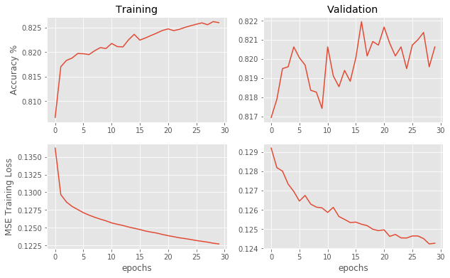

```python
from matplotlib import pyplot as plt

%matplotlib inline

plt.figure(figsize=(10,6))
plt.subplot(2,2,1)
plt.plot(history1.history['acc'])

plt.ylabel('Accuracy %')
plt.title('Training')
plt.subplot(2,2,2)
plt.plot(history1.history['val_acc'])
plt.title('Validation')

plt.subplot(2,2,3)
plt.plot(history1.history['loss'])
plt.ylabel('MSE Training Loss')
plt.xlabel('epochs')

plt.subplot(2,2,4)
plt.plot(history1.history['val_loss'])
plt.xlabel('epochs')
```

For train vs loss, I think it converge, the line reach the bottom. For validation, the line boucing around but keep going down. In general, they converge. i think 30 epochs is fine.

```python
#https://github.com/Thakugan/machine-learning-notebooks/blob/master/6-wide-and-deep-networks/mushroom-hunting.ipynb
num_folds = 5

acc_scores1 =[]
fn_scores1 = []

skf = StratifiedKFold(n_splits=num_folds, shuffle=True)
for i, (train, test) in enumerate(skf.split(X, y)):#here I used corss validation on my model

    model1, X_ints_train, X_ints_test, X_train_num = create_model1(X_train, X_test, X_train_num, categorical_headers_ints, cross_columns2)

    model1.compile(optimizer='adagrad',
                  loss='mean_squared_error',
                  metrics=['accuracy'])

    model1.fit(X_ints_train + [X_train_num], y_train, epochs=30, batch_size=50, verbose=1)
#this is just what i do with out cross validation
    yhat = np.round(model1.predict(X_ints_test + [X_test_num]))
    print(mt.confusion_matrix(y_test,yhat))
    acc_score1 = mt.accuracy_score(y_test, yhat)
    acc_scores1.append(acc_score1)#append all acc for k-fold
    fn_score1 = custom_score(y_test,yhat)
    fn_scores1.append(fn_score1)#append all fn for k-fold
    print("Accuracy: ", acc_score1)
    print("Fn : ", fn_score1)
print(fn_scores1)
print(acc_scores1)
```

[output not shown]

# Different layers

## Model1 with 7 layer in Deep and cross combo1

```python
#model1
from keras.layers import concatenate
from sklearn.preprocessing import OneHotEncoder

#'HEAT_D','AC','QUALIFIED','STRUCT_D','CNDTN_D','ROOF_D','INTWALL_D'
#"BATHRM","BEDRM","AYB_year","YR_RMDL_year","EYB_year","STORAGE","GBA","KITCHENS"
cross_columns1 = [['HEAT_D','AC'],
                 ['QUALIFIED', 'CNDTN_D'],
                 ['ROOF_D','INTWALL_D']]

# and save off the numeric features
X_train_num =  df_train[numeric_headers].values
X_test_num = df_test[numeric_headers].values


def create_model2(X_train, X_test, X_train_num, categorical_headers_ints, cross_columns=cross_columns1):
    embed_branches = []
    X_ints_train = []
    X_ints_test = []
    all_inputs = []
    all_wide_branch_outputs = []

    for cols in cross_columns:
    # encode crossed columns as ints for the embedding
        enc = LabelEncoder()

    # create crossed labels
        X_crossed_train = df_train[cols].apply(lambda x: '_'.join(x), axis=1)
        X_crossed_test = df_test[cols].apply(lambda x: '_'.join(x), axis=1)

        enc.fit(np.hstack((X_crossed_train.values,  X_crossed_test.values)))
        X_crossed_train = enc.transform(X_crossed_train)
        X_crossed_test = enc.transform(X_crossed_test)
        X_ints_train.append( X_crossed_train )
        X_ints_test.append( X_crossed_test )

    # get the number of categories
        N = max(X_ints_train[-1]+1) # same as the max(df_train[col])

    # create embedding branch from the number of categories
        inputs = Input(shape=(1,),dtype='int32', name = '_'.join(cols))
        all_inputs.append(inputs)
        x = Embedding(input_dim=N,
                  output_dim=int(np.sqrt(N)),
                  input_length=1, name = '_'.join(cols)+'_embed')(inputs)
        x = Flatten()(x)
        all_wide_branch_outputs.append(x)

# merge the branches together
    wide_branch = concatenate(all_wide_branch_outputs, name='wide_concat')
    wide_branch = Dense(units=1,activation='sigmoid',name='wide_combined')(wide_branch)

# reset this input branch
    all_deep_branch_outputs = []
# add in the embeddings
    for col in categorical_headers_ints:
    # encode as ints for the embedding
        X_ints_train.append( df_train[col].values )
        X_ints_test.append( df_test[col].values )

    # get the number of categories
        N = max(X_ints_train[-1]+1) # same as the max(df_train[col])

    # create embedding branch from the number of categories
        inputs = Input(shape=(1,),dtype='int32', name=col)
        all_inputs.append(inputs)
        x = Embedding(input_dim=N,
                  output_dim=int(np.sqrt(N)),
                  input_length=1, name=col+'_embed')(inputs)
        x = Flatten()(x)
        all_deep_branch_outputs.append(x)

# also get a dense branch of the numeric features
    all_inputs.append(Input(shape=(X_train_num.shape[1],),
                            sparse=False,
                            name='numeric_data'))

    x = Dense(units=20, activation='relu',name='numeric_1')(all_inputs[-1])
    all_deep_branch_outputs.append( x )

# merge the deep branches together
    deep_branch = concatenate(all_deep_branch_outputs,name='concat_embeds')
    deep_branch = Dense(units=50,activation='relu', name='deep1')(deep_branch)
    deep_branch = Dense(units=25,activation='relu', name='deep2')(deep_branch)
    deep_branch = Dense(units=10,activation='relu', name='deep3')(deep_branch)
    deep_branch = Dense(units=10,activation='relu', name='deep4')(deep_branch)
    deep_branch = Dense(units=10,activation='relu', name='deep5')(deep_branch)
    deep_branch = Dense(units=10,activation='relu', name='deep6')(deep_branch)
    deep_branch = Dense(units=10,activation='relu', name='deep7')(deep_branch)

    final_branch = concatenate([wide_branch, deep_branch],name='concat_deep_wide')
    final_branch = Dense(units=1,activation='sigmoid',name='combined')(final_branch)

    model2 = Model(inputs=all_inputs, outputs=final_branch)
    return model2, X_ints_train, X_ints_test, X_train_num
```

```python
from IPython.display import SVG
from keras.utils.vis_utils import model_to_dot

# you will need to install pydot properly on your machine to get this running
SVG(model_to_dot(model).create(prog='dot', format='svg'))
```

[figure not shown]

```python
model2.compile(optimizer='adagrad',
              loss='mean_squared_error',
              metrics=['accuracy'])
```

```python
# lets also add the history variable to see how we are doing
# and lets add a validation set to keep track of our progress
history2 = model2.fit(X_ints_train+ [X_train_num],
                    y_train,
                    epochs=30,
                    batch_size=50,
                    verbose=1,
                    validation_data = (X_ints_test + [X_test_num], y_test))
```

```
Train on 42388 samples, validate on 10598 samples
```

```python
#accuracy score
yhat = np.round(model2.predict(X_ints_test + [X_test_num]))
print(mt.confusion_matrix(y_test,yhat), 'Accuracy ',mt.accuracy_score(y_test,yhat))
#my FN score
print('FN score ',custom_score(y_test,yhat))
```

```
[[6627  750]
 [1095 2126]] Accuracy  0.8259105491602189
FN score  0.5934959349593496
```

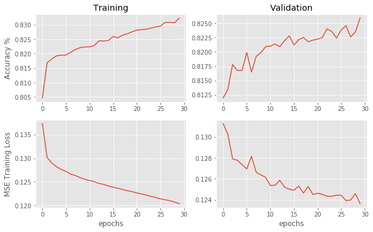

```python
from matplotlib import pyplot as plt

%matplotlib inline

plt.figure(figsize=(10,6))
plt.subplot(2,2,1)
plt.plot(history2.history['acc'])

plt.ylabel('Accuracy %')
plt.title('Training')
plt.subplot(2,2,2)
plt.plot(history2.history['val_acc'])
plt.title('Validation')

plt.subplot(2,2,3)
plt.plot(history2.history['loss'])
plt.ylabel('MSE Training Loss')
plt.xlabel('epochs')

plt.subplot(2,2,4)
plt.plot(history2.history['val_loss'])
plt.xlabel('epochs')
```

For train vs loss, I think it converge, the line reach the bottom. For validation, the line boucing around but it converge. In general, they converge. I think 30 epochs is fine.

```python
#https://github.com/Thakugan/machine-learning-notebooks/blob/master/6-wide-and-deep-networks/mushroom-hunting.ipynb
num_folds = 5

acc_scores2 =[]
fn_scores2 = []

skf = StratifiedKFold(n_splits=num_folds, shuffle=True)
for i, (train, test) in enumerate(skf.split(X, y)):#here I used corss validation on my model

    model2, X_ints_train, X_ints_test, X_train_num = create_model2(X_train, X_test, X_train_num, categorical_headers_ints, cross_columns1)

    model2.compile(optimizer='adagrad',
                  loss='mean_squared_error',
                  metrics=['accuracy'])

    model2.fit(X_ints_train + [X_train_num], y_train, epochs=30, batch_size=50, verbose=1)
#this is just what i do with out cross validation
    yhat = np.round(model2.predict(X_ints_test + [X_test_num]))
    print(mt.confusion_matrix(y_test,yhat))
    acc_score2 = mt.accuracy_score(y_test, yhat)
    acc_scores2.append(acc_score2)#append all acc for k-fold
    fn_score2 = custom_score(y_test,yhat)
    fn_scores2.append(fn_score2)#append all fn for k-fold
    print("Accuracy: ", acc_score2)
    print("Fn : ", fn_score2)
print(fn_scores2)
print(acc_scores2)
```

```
[[6619  758]
 [1101 2120]]
Accuracy:  0.8245895451972071
Fn :  0.5922538999462076
[[6706  671]
 [1200 2021]]
Accuracy:  0.823457256086054
Fn :  0.6413682522715125
[[6653  724]
 [1167 2054]]
Accuracy:  0.8215701075674655
Fn :  0.6171337916446324
[[6642  735]
 [1170 2051]]
Accuracy:  0.8202491036044537
Fn :  0.6141732283464567
[[6649  728]
 [1163 2058]]
Accuracy:  0.8215701075674655
Fn :  0.6150185087255421
[0.5922538999462076, 0.6413682522715125, 0.6171337916446324, 0.6141732283464567, 0.6150185087255421]
[0.8245895451972071, 0.823457256086054, 0.8215701075674655, 0.8202491036044537, 0.8215701075674655]
```

## Model2 with 7 layer in Deep and cross combo2

```python
#model2
from keras.layers import concatenate
from sklearn.preprocessing import OneHotEncoder

#'HEAT_D','AC','QUALIFIED','STRUCT_D','CNDTN_D','ROOF_D','INTWALL_D'
#"BATHRM","BEDRM","AYB_year","YR_RMDL_year","EYB_year","STORAGE","GBA","KITCHENS"
cross_columns2 = [['HEAT_D','INTWALL_D'],
                 ['AC', 'ROOF_D'],
                 ['ROOF_D','INTWALL_D','STRUCT_D']]

# and save off the numeric features
X_train_num =  df_train[numeric_headers].values
X_test_num = df_test[numeric_headers].values

#def create_model this just add in frount of original Dr. Larson code, doing this for cross validation
def create_model3(X_train, X_test, X_train_num, categorical_headers_ints, cross_columns=cross_columns2):
    embed_branches = []
    X_ints_train = []
    X_ints_test = []
    all_inputs = []
    all_wide_branch_outputs = []

    for cols in cross_columns:
    # encode crossed columns as ints for the embedding
        enc = LabelEncoder()

    # create crossed labels
        X_crossed_train = df_train[cols].apply(lambda x: '_'.join(x), axis=1)
        X_crossed_test = df_test[cols].apply(lambda x: '_'.join(x), axis=1)

        enc.fit(np.hstack((X_crossed_train.values,  X_crossed_test.values)))
        X_crossed_train = enc.transform(X_crossed_train)
        X_crossed_test = enc.transform(X_crossed_test)
        X_ints_train.append( X_crossed_train )
        X_ints_test.append( X_crossed_test )

    # get the number of categories
        N = max(X_ints_train[-1]+1) # same as the max(df_train[col])

    # create embedding branch from the number of categories
        inputs = Input(shape=(1,),dtype='int32', name = '_'.join(cols))
        all_inputs.append(inputs)
        x = Embedding(input_dim=N,
                  output_dim=int(np.sqrt(N)),
                  input_length=1, name = '_'.join(cols)+'_embed')(inputs)
        x = Flatten()(x)
        all_wide_branch_outputs.append(x)

# merge the branches together
    wide_branch = concatenate(all_wide_branch_outputs, name='wide_concat')
    wide_branch = Dense(units=1,activation='sigmoid',name='wide_combined')(wide_branch)

# reset this input branch
    all_deep_branch_outputs = []
# add in the embeddings
    for col in categorical_headers_ints:
    # encode as ints for the embedding
        X_ints_train.append( df_train[col].values )
        X_ints_test.append( df_test[col].values )

    # get the number of categories
        N = max(X_ints_train[-1]+1) # same as the max(df_train[col])

    # create embedding branch from the number of categories
        inputs = Input(shape=(1,),dtype='int32', name=col)
        all_inputs.append(inputs)
        x = Embedding(input_dim=N,
                  output_dim=int(np.sqrt(N)),
                  input_length=1, name=col+'_embed')(inputs)
        x = Flatten()(x)
        all_deep_branch_outputs.append(x)

# also get a dense branch of the numeric features
    all_inputs.append(Input(shape=(X_train_num.shape[1],),
                            sparse=False,
                            name='numeric_data'))

    x = Dense(units=20, activation='relu',name='numeric_1')(all_inputs[-1])
    all_deep_branch_outputs.append( x )

# merge the deep branches together
    deep_branch = concatenate(all_deep_branch_outputs,name='concat_embeds')
    deep_branch = Dense(units=50,activation='relu', name='deep1')(deep_branch)
    deep_branch = Dense(units=25,activation='relu', name='deep2')(deep_branch)
    deep_branch = Dense(units=10,activation='relu', name='deep3')(deep_branch)
    deep_branch = Dense(units=10,activation='relu', name='deep4')(deep_branch)
    deep_branch = Dense(units=10,activation='relu', name='deep5')(deep_branch)
    deep_branch = Dense(units=10,activation='relu', name='deep6')(deep_branch)
    deep_branch = Dense(units=10,activation='relu', name='deep7')(deep_branch)

    final_branch = concatenate([wide_branch, deep_branch],name='concat_deep_wide')
    final_branch = Dense(units=1,activation='sigmoid',name='combined')(final_branch)

    model2 = Model(inputs=all_inputs, outputs=final_branch)
    return model2, X_ints_train, X_ints_test, X_train_num
```

```python
from IPython.display import SVG
from keras.utils.vis_utils import model_to_dot

# you will need to install pydot properly on your machine to get this running
SVG(model_to_dot(model).create(prog='dot', format='svg'))
```

[figure not shown]

```python
model3.compile(optimizer='adagrad',
              loss='mean_squared_error',
              metrics=['accuracy'])
```

```python
# lets also add the history variable to see how we are doing
# and lets add a validation set to keep track of our progress
history3 = model3.fit(X_ints_train+ [X_train_num],
                    y_train,
                    epochs=30,
                    batch_size=50,
                    verbose=1,
                    validation_data = (X_ints_test + [X_test_num], y_test))
```

```
Train on 42388 samples, validate on 10598 samples
```

```python
#accuracy score
yhat = np.round(model.predict(X_ints_test + [X_test_num]))
print(mt.confusion_matrix(y_test,yhat), 'Accuracy ',mt.accuracy_score(y_test,yhat))
#my FN score
print('FN score ',custom_score(y_test,yhat))
```

```
[[6646  731]
 [1139 2082]] Accuracy  0.8235516135119834
FN score  0.6090909090909091
```

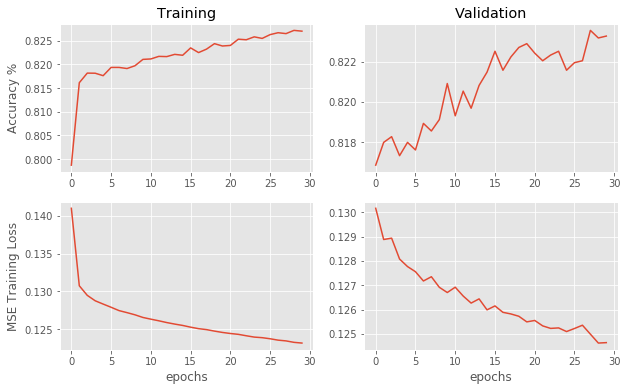

```python
from matplotlib import pyplot as plt

%matplotlib inline

plt.figure(figsize=(10,6))
plt.subplot(2,2,1)
plt.plot(history3.history['acc'])

plt.ylabel('Accuracy %')
plt.title('Training')
plt.subplot(2,2,2)
plt.plot(history3.history['val_acc'])
plt.title('Validation')

plt.subplot(2,2,3)
plt.plot(history3.history['loss'])
plt.ylabel('MSE Training Loss')
plt.xlabel('epochs')

plt.subplot(2,2,4)
plt.plot(history3.history['val_loss'])
plt.xlabel('epochs')
```

For train vs loss, I think it converge, the line reach the bottom. For validation, the line boucing around but it converge. In general, they converge. I think 30 epochs is fine.

```python
#https://github.com/Thakugan/machine-learning-notebooks/blob/master/6-wide-and-deep-networks/mushroom-hunting.ipynb
num_folds = 5

acc_scores3 =[]
fn_scores3 = []

skf = StratifiedKFold(n_splits=num_folds, shuffle=True)
for i, (train, test) in enumerate(skf.split(X, y)):#here I used corss validation on my model

    model3, X_ints_train, X_ints_test, X_train_num = create_model3(X_train, X_test, X_train_num, categorical_headers_ints, cross_columns2)

    model3.compile(optimizer='adagrad',
                  loss='mean_squared_error',
                  metrics=['accuracy'])

    model3.fit(X_ints_train + [X_train_num], y_train, epochs=30, batch_size=50, verbose=1)
#this is just what i do with out cross validation
    yhat = np.round(model3.predict(X_ints_test + [X_test_num]))
    print(mt.confusion_matrix(y_test,yhat))
    acc_score3 = mt.accuracy_score(y_test, yhat)
    acc_scores3.append(acc_score3)#append all acc for k-fold
    fn_score3 = custom_score(y_test,yhat)
    fn_scores3.append(fn_score3)#append all fn for k-fold
    print("Accuracy: ", acc_score3)
    print("Fn : ", fn_score3)
print(fn_scores3)
print(acc_scores3)
```

```
[[6554  823]
 [1071 2150]]
Accuracy:  0.8212870352896773
Fn :  0.5654699049630412
[[6658  719]
 [1172 2049]]
Accuracy:  0.8215701075674655
Fn :  0.6197778952934955
[[6757  620]
 [1241 1980]]
Accuracy:  0.8244008303453482
Fn :  0.6668457818377217
[[6647  730]
 [1141 2080]]
Accuracy:  0.823457256086054
Fn :  0.6098343132014965
[[6692  685]
 [1150 2071]]
Accuracy:  0.8268541234195131
Fn :  0.6267029972752044
[0.5654699049630412, 0.6197778952934955, 0.6668457818377217, 0.6098343132014965, 0.6267029972752044]
[0.8212870352896773, 0.8215701075674655, 0.8244008303453482, 0.823457256086054, 0.8268541234195131]
```

# Compare different models

Model1 layer3:

- Accuracy 0.8235516135119834
- FN score 0.6090909090909091

Model2 layer3:

- Accuracy 0.8243064729194187
- FN score 0.583780880773362

Model1 layer7:

- Accuracy 0.8259105491602189
- FN score 0.5934959349593496

# model1 kayer3 vs model2 layer3

```python
#model1 kayer3 vs model2 layer3 acc
t = 2.26 / np.sqrt(10)
e = (1-np.array(acc_scores))-(1-np.array(acc_scores1))
stdtot =np.std(e)

dbar = np.mean(e)
print('model1 kayer3 vs model2 layer3 acc range :',dbar-t*stdtot,dbar+t*stdtot)
```

```
model1 kayer3 vs model2 layer3 acc range : -0.0020848617107025436 0.002726492207022611
```

Becasue the range is include 0, so we can not say that with 95% confident level, model1 kayer3 and model2 layer3 are statisitcally different base on accuracy.

```python
#model1 kayer3 vs model2 layer3 fn
t = 2.26 / np.sqrt(10)
e = (1-np.array(fn_scores))-(1-np.array(fn_scores1))
stdtot =np.std(e)

dbar = np.mean(e)
print('model1 kayer3 vs model2 layer3 fn range :',dbar-t*stdtot,dbar+t*stdtot)
```

```
model1 kayer3 vs model2 layer3 fn range : -0.019409982824137216 0.004836035234390867
```

Becasue the range is include 0, so we can not say that with 95% confident level, model1 kayer3 and model2 layer3 are statisitcally different base on FN score.

```python
print('Mean acc model1 3layer ',np.mean(np.array(acc_scores)))
print('Mean acc model2 3layer ',np.mean(np.array(acc_scores1)))
```

```
Mean acc model1 3layer  0.823287412719381
Mean acc model2 3layer  0.823608227967541
```

```python
print('Mean fn model1 3layer ',np.mean(np.array(fn_scores)))
print('Mean fn model2 3layer ',np.mean(np.array(fn_scores1)))
```

```
Mean fn model1 3layer  0.5996149422379874
Mean fn model2 3layer  0.5923279684431142
```

Base on sttisitcal result, we can not say who is better than who. However, Both fn and acc of Model2 3layer is little bit better than medal1 3 layer. So I still think model2 3 layer is better.

# model1 kayer7 vs model2 layer7

```python
#model1 kayer7 vs model2 layer7 acc
t = 2.26 / np.sqrt(10)
e = (1-np.array(acc_scores2))-(1-np.array(acc_scores3))
stdtot =np.std(e)

dbar = np.mean(e)
print('model1 kayer7 vs model2 layer7 acc range :',dbar-t*stdtot,dbar+t*stdtot)
```

```
model1 kayer7 vs model2 layer7 acc range : -0.0011039088106156495 0.0035572018847805803
```

Becasue the range is include 0, so we can not say that with 95% confident level, model1 kayer7 and model2 layer7 are statisitcally different base on accuracy score.

```python
#model1 kayer7 vs model2 layer7 fn
t = 2.26 / np.sqrt(10)
e = (1-np.array(fn_scores2))-(1-np.array(fn_scores3))
stdtot =np.std(e)

dbar = np.mean(e)
print('model1 kayer7 vs model2 layer7 fn range :',dbar-t*stdtot,dbar+t*stdtot)
```

```
model1 kayer7 vs model2 layer7 fn range : -0.01795282656640379 0.02142611122104695
```

Becasue the range is include 0, so we can not say that with 95% confident level, model1 kayer7 and model2 layer7 are statisitcally different base on FN score.

```python
print('Mean acc model1 7layer ',np.mean(np.array(acc_scores2)))
print('Mean acc model2 7layer ',np.mean(np.array(acc_scores3)))
```

```
Mean acc model1 7layer  0.8222872240045291
Mean acc model2 7layer  0.8235138705416116
```

```python
print('Mean fn model1 7layer ',np.mean(np.array(fn_scores2)))
print('Mean fn model2 7layer ',np.mean(np.array(fn_scores3)))
```

```
Mean fn model1 7layer  0.6159895361868704
Mean fn model2 7layer  0.6177261785141919
```

Base on sttisitcal result, we can not say who is better than who. However, acc of Model2 7layer is little bit better than medal1 7 layer. And fn of model1 7layer is better. So I still think model2 7 layer is better because it have better accuracy.

# model1 kayer3 vs model1 layer7

```python
#model1 kayer3 vs model1 layer7 acc
t = 2.26 / np.sqrt(10)
e = (1-np.array(acc_scores))-(1-np.array(acc_scores2))
stdtot =np.std(e)

dbar = np.mean(e)
print('model1 kayer3 vs model1 layer7 acc range :',dbar-t*stdtot,dbar+t*stdtot)
```

```
model1 kayer3 vs model1 layer7 acc range : -0.002823974713825091 0.0008235972841214207
```

Becasue the range is include 0, so we can not say that with 95% confident level, model1 kayer3 and model1 layer7 are statisitcally different base on accuracy score.

```python
#model1 kayer3 vs model1 layer7 fn
t = 2.26 / np.sqrt(10)
e = (1-np.array(fn_scores))-(1-np.array(fn_scores2))
stdtot =np.std(e)

dbar = np.mean(e)
print('model1 kayer3 vs model1 layer7 fn range :',dbar-t*stdtot,dbar+t*stdtot)
```

```
model1 kayer3 vs model1 layer7 fn range : 0.0026688743423036836 0.030080313555462115
```

Becasue the range is not include 0, so we can say that with 95% confident level, model1 kayer3 and model1 layer7 are statisitcally different base on FN score.

```python
print('Mean acc model1 3layer ',np.mean(np.array(acc_scores)))
print('Mean acc model2 7layer ',np.mean(np.array(acc_scores2)))
```

```
Mean acc model1 3layer  0.823287412719381
Mean acc model2 7layer  0.8222872240045291
```

```python
print('Mean fn model1 3layer ',np.mean(np.array(fn_scores)))
print('Mean fn model2 7layer ',np.mean(np.array(fn_scores2)))
```

```
Mean fn model1 3layer  0.5996149422379874
Mean fn model2 7layer  0.6159895361868704
```

Base on sttisitcal result of FN, we can say they are different. Both acc and FN of Model1 3layer is little bit better than medal1 7 layer. So I think model1 3 layer is better.

# model2 kayer3 vs model2 layer7

```python
#model2 kayer3 vs model2 layer7 acc
t = 2.26 / np.sqrt(10)
e = (1-np.array(acc_scores1))-(1-np.array(acc_scores3))
stdtot =np.std(e)

dbar = np.mean(e)
print('model2 kayer3 vs model2 layer7 acc range :',dbar-t*stdtot,dbar+t*stdtot)
```

```
model2 kayer3 vs model2 layer7 acc range : -0.0017522132213550997 0.0015634983694962931
```

Becasue the range is include 0, so we can not say that with 95% confident level, model2 kayer3 and model2 layer7 are statisitcally different base on accuracy score.

```python
#model1 kayer7 vs model2 layer7 fn
t = 2.26 / np.sqrt(10)
e = (1-np.array(fn_scores1))-(1-np.array(fn_scores3))
stdtot =np.std(e)

dbar = np.mean(e)
print('model2 kayer3 vs model2 layer7 fn range :',dbar-t*stdtot,dbar+t*stdtot)
```

```
model2 kayer3 vs model2 layer7 fn range : -0.011572829058021553 0.06236924920017686
```

Becasue the range is include 0, so we can not say that with 95% confident level, model2 kayer3 and model2 layer7 are statisitcally different base on FN score.

```python
print('Mean acc model2 3layer ',np.mean(np.array(acc_scores1)))
print('Mean acc model2 7layer ',np.mean(np.array(acc_scores3)))
```

```
Mean acc model2 3layer  0.823608227967541
Mean acc model2 7layer  0.8235138705416116
```

```python
print('Mean fn model2 3layer ',np.mean(np.array(fn_scores1)))
print('Mean fn model2 7layer ',np.mean(np.array(fn_scores3)))
```

```
Mean fn model2 3layer  0.5923279684431142
Mean fn model2 7layer  0.6177261785141919
```

Base on sttisitcal result, we can not say they are different. Both acc and FN of Model2 3layer is little bit better than medal2 7 layer. So I think model2 3 layer is better.

Overall, base on 4 comparision, Model2 layer3 is the best I think.

# MLP

```python
from sklearn.neural_network import MLPClassifier
from sklearn.preprocessing import OneHotEncoder
ohe = OneHotEncoder()
X_train_ohe = ohe.fit_transform(df_train[categorical_headers_ints].values)
X_test_ohe = ohe.transform(df_test[categorical_headers_ints].values)

# and save off the numeric features
X_train_num =  df_train[numeric_headers].values
X_test_num = df_test[numeric_headers].values
```

```python
from sklearn.neural_network import MLPClassifier
mlp = MLPClassifier(hidden_layer_sizes=(50,),
                       solver='sgd',
                       learning_rate_init=0.01,
                       max_iter=100,
                       random_state=1)
```

```python
#https://stackoverflow.com/questions/25453173/numpy-array-concatenation-error-0-d-arrays-cant-be-concatenated
#np.concatenate() doesn't work with sparse matrices. i use np.concatenate([B.todense(),A]).
x_train = np.concatenate((X_train_ohe.todense(), X_train_num), axis=1)#concatenate categorical variables and numeric variables
y_train = y_train
x_test = np.concatenate((X_test_ohe.todense(), X_test_num), axis=1)
y_test = y_test
```

```python
%%time
mlp.fit(x_train, y_train)
#accuracy score
yhat = mlp.predict(x_test)
print(mt.confusion_matrix(y_test,yhat), 'Accuracy ',mt.accuracy_score(y_test,yhat))
#my FN score
print('FN score ',custom_score(y_test,yhat))
```

[output not shown]

```python
acc_scores4 = []
fn_scores4 = []

skf = StratifiedKFold(n_splits=num_folds, shuffle=True)
for i, (train, test) in enumerate(skf.split(X, y)):

    mlp.fit(x_train, y_train)

    yhat = mlp.predict(x_test)
    print(mt.confusion_matrix(y_test,yhat))
    acc_score4 = mt.accuracy_score(y_test, yhat)
    acc_scores4.append(acc_score4)#append all acc for k-fold
    fn_score4 = custom_score(y_test,yhat)
    fn_scores4.append(fn_score4)#append all fn for k-fold
    print("Accuracy: ", acc_score4)
    print("Fn : ", fn_score4)
print(fn_scores4)
print(acc_scores4)
```

```
[[6711  595]
 [1339 1953]]
Accuracy:  0.8175127382525005
Fn :  0.6923474663908997
[[6711  595]
 [1339 1953]]
Accuracy:  0.8175127382525005
Fn :  0.6923474663908997
[[6711  595]
 [1339 1953]]
Accuracy:  0.8175127382525005
Fn :  0.6923474663908997
[[6711  595]
 [1339 1953]]
Accuracy:  0.8175127382525005
Fn :  0.6923474663908997
[[6711  595]
 [1339 1953]]
Accuracy:  0.8175127382525005
Fn :  0.6923474663908997
[0.6923474663908997, 0.6923474663908997, 0.6923474663908997, 0.6923474663908997, 0.6923474663908997]
[0.8175127382525005, 0.8175127382525005, 0.8175127382525005, 0.8175127382525005, 0.8175127382525005]
```

```
Area under the curve(AUC) is  0.7658001681387965
```

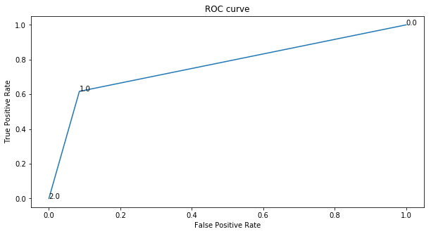

```python
#I used this on ICA1 and just copy from my old work
#https://scikit-learn.org/stable/modules/generated/sklearn.metrics.roc_curve.html
from sklearn.metrics import roc_curve, roc_auc_score
import numpy as np
import matplotlib.pyplot
import matplotlib.pyplot as plt

fpr, tpr, thresholds = roc_curve(y_test, yhat)
threshold = np.round(thresholds, decimals=2)


plt.figure(figsize=(10,5))
plt.plot(fpr,tpr)
labels = [threshold[i] for i in range(3)]
for i in range (3):
    xy=(fpr[i],tpr[i])
    plt.annotate(labels[i],xy)

plt.xlabel('False Positive Rate')
plt.ylabel('True Positive Rate')
plt.title('ROC curve')
print('Area under the curve(AUC) is ',roc_auc_score(y_test, yhat))
```

For this one, from roc curve, I calculate the area under curve is 0.76.

```python
# lets also add the history variable to see how we are doing
# and lets add a validation set to keep track of our progress
history1 = model.fit(X_ints_train+ [X_train_num],
                    y_train,
                    epochs=20,
                    batch_size=50,
                    verbose=1,
                    validation_data = (X_ints_test + [X_test_num], y_test))
```

```
Train on 42388 samples, validate on 10598 samples
```

```python
#accuracy score
yhat = np.round(model.predict(X_ints_test + [X_test_num]))
print(mt.confusion_matrix(y_test,yhat), 'Accuracy ',mt.accuracy_score(y_test,yhat))
#my FN score
print('FN score ',custom_score(y_test,yhat))
```

```
[[6800  705]
 [1103 1990]] Accuracy  0.8294017739196075
FN score  0.610066371681416
```

```
Area under the curve(AUC) is  0.7747254605346625
```

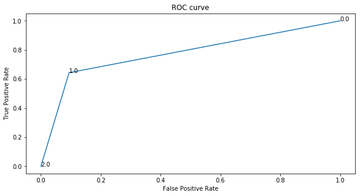

```python
#I used this on ICA1 and just copy from my old work
#https://scikit-learn.org/stable/modules/generated/sklearn.metrics.roc_curve.html
from sklearn.metrics import roc_curve, roc_auc_score
import numpy as np
import matplotlib.pyplot
import matplotlib.pyplot as plt

fpr, tpr, thresholds = roc_curve(y_test, yhat)
threshold = np.round(thresholds, decimals=2)


plt.figure(figsize=(10,5))
plt.plot(fpr,tpr)
labels = [threshold[i] for i in range(3)]
for i in range (3):
    xy=(fpr[i],tpr[i])
    plt.annotate(labels[i],xy)

plt.xlabel('False Positive Rate')
plt.ylabel('True Positive Rate')
plt.title('ROC curve')
print('Area under the curve(AUC) is ',roc_auc_score(y_test, yhat))
```

For this one, from roc curve, I calculate the area under curve is 0.77.

```python
#model2 kayer3 vs mlp
t = 2.26 / np.sqrt(10)
e = (1-np.array(acc_scores1))-(1-np.array(acc_scores4))
stdtot =np.std(e)

dbar = np.mean(e)
print('model2 layer3 vs mlp acc range :',dbar-t*stdtot,dbar+t*stdtot)
```

```
model2 layer3 vs mlp acc range : -0.007178318195991879 -0.005012661234089216
```

Becasue the range is not include 0, so we can say that with 95% confident level, model2 layer3 and mlp are statisitcally different base on acc score.

```python
#model2 kayer3 vs mlp
t = 2.26 / np.sqrt(10)
e = (1-np.array(fn_scores1))-(1-np.array(fn_scores4))
stdtot =np.std(e)

dbar = np.mean(e)
print('model2 layer3 vs mlp fn range :',dbar-t*stdtot,dbar+t*stdtot)
```

```
model2 layer3 vs mlp fn range : 0.08386956769253306 0.116169428203038
```

Becasue the range is not include 0, so we can say that with 95% confident level, model2 layer3 and mlp are statisitcally different base on FN score.

```python
print('Mean acc model2 3layer ',np.mean(np.array(acc_scores1)))
print('Mean acc mlp ',np.mean(np.array(acc_scores4)))
```

```
Mean acc model2 3layer  0.823608227967541
Mean acc mlp  0.8175127382525005
```

```python
print('Mean fn model2 3layer ',np.mean(np.array(fn_scores1)))
print('Mean fn mlp ',np.mean(np.array(fn_scores4)))
```

```
Mean fn model2 3layer  0.5923279684431142
Mean fn mlp  0.6923474663908997
```

By comparing the accuracy, FN score and statistical method, my model is better than mlp.

# Exceptional Work

```python
from keras.layers import concatenate
from sklearn.preprocessing import OneHotEncoder
#model2
#'HEAT_D','AC','QUALIFIED','STRUCT_D','CNDTN_D','ROOF_D','INTWALL_D'
#"BATHRM","BEDRM","AYB_year","YR_RMDL_year","EYB_year","STORAGE","GBA","KITCHENS"
cross_columns = [['HEAT_D','INTWALL_D'],
                 ['AC', 'ROOF_D'],
                 ['ROOF_D','INTWALL_D','STRUCT_D']]


# and save off the numeric features
X_train_num =  df_train[numeric_headers].values
X_test_num = df_test[numeric_headers].values


# we need to create separate lists for each branch
embed_branches = []
X_ints_train = []
X_ints_test = []
all_inputs = []
all_wide_branch_outputs = []

for cols in cross_columns:
    # encode crossed columns as ints for the embedding
    enc = LabelEncoder()

    # create crossed labels
    X_crossed_train = df_train[cols].apply(lambda x: '_'.join(x), axis=1)
    X_crossed_test = df_test[cols].apply(lambda x: '_'.join(x), axis=1)

    enc.fit(np.hstack((X_crossed_train.values,  X_crossed_test.values)))
    X_crossed_train = enc.transform(X_crossed_train)
    X_crossed_test = enc.transform(X_crossed_test)
    X_ints_train.append( X_crossed_train )
    X_ints_test.append( X_crossed_test )

    # get the number of categories
    N = max(X_ints_train[-1]+1) # same as the max(df_train[col])

    # create embedding branch from the number of categories
    inputs = Input(shape=(1,),dtype='int32', name = '_'.join(cols))
    all_inputs.append(inputs)
    x = Embedding(input_dim=N,
                  output_dim=int(np.sqrt(N)),
                  input_length=1, name = '_'.join(cols)+'_embed')(inputs)
    x = Flatten()(x)
    all_wide_branch_outputs.append(x)

# merge the branches together
wide_branch = concatenate(all_wide_branch_outputs, name='wide_concat')
wide_branch = Dense(units=1,activation='sigmoid',name='wide_combined')(wide_branch)

# reset this input branch
all_deep_branch_outputs = []
# add in the embeddings
for col in categorical_headers_ints:
    # encode as ints for the embedding
    X_ints_train.append( df_train[col].values )
    X_ints_test.append( df_test[col].values )

    # get the number of categories
    N = max(X_ints_train[-1]+1) # same as the max(df_train[col])

    # create embedding branch from the number of categories
    inputs = Input(shape=(1,),dtype='int32', name=col)
    all_inputs.append(inputs)
    x = Embedding(input_dim=N,
                  output_dim=int(np.sqrt(N)),
                  input_length=1, name=col+'_embed')(inputs)
    x = Flatten()(x)
    all_deep_branch_outputs.append(x)

# also get a dense branch of the numeric features
all_inputs.append(Input(shape=(X_train_num.shape[1],),
                        sparse=False,
                        name='numeric_data'))

x = Dense(units=20, activation='relu',name='numeric_1')(all_inputs[-1])
all_deep_branch_outputs.append( x )

# merge the deep branches together
deep_branch = concatenate(all_deep_branch_outputs,name='concat_embeds')
deep_branch = Dense(units=50,activation='relu', name='deep1')(deep_branch)
deep_branch = Dense(units=25,activation='relu', name='deep2')(deep_branch)
deep_branch = Dense(units=10,activation='relu', name='deep3')(deep_branch)

final_branch = concatenate([wide_branch, deep_branch],name='concat_deep_wide')
final_branch = Dense(units=1,activation='sigmoid',name='combined')(final_branch)

model = Model(inputs=all_inputs, outputs=final_branch)
```

```python
model.compile(optimizer='adagrad',
              loss='mean_squared_error',
              metrics=['accuracy'])
```

```python
# lets also add the history variable to see how we are doing
# and lets add a validation set to keep track of our progress
history1 = model.fit(X_ints_train+ [X_train_num],
                    y_train,
                    epochs=20,
                    batch_size=50,
                    verbose=1,
                    validation_data = (X_ints_test + [X_test_num], y_test))
```

```
Train on 42388 samples, validate on 10598 samples
```

```python
#https://github.com/Thakugan/machine-learning-notebooks/blob/master/6-wide-and-deep-networks/mushroom-hunting.ipynb
#by using for loop, I can get all categorical variables
weights_int = []
for ind in model.layers:
    if '_int' in ind.name:
        print(ind.name)#this will return me all categorical variables with both embed and int, what we want is embed
        weights_int.append(ind.get_weights())#append all weight from those categorical variables
```

```
HEAT_D_int
AC_int
QUALIFIED_int
STRUCT_D_int
CNDTN_D_int
ROOF_D_int
INTWALL_D_int
HEAT_D_int_embed
AC_int_embed
QUALIFIED_int_embed
STRUCT_D_int_embed
CNDTN_D_int_embed
ROOF_D_int_embed
INTWALL_D_int_embed
```

```python
#ROOF_D is what I am interested
np.array(weights_int)[12]
```

```
[array([[ 0.0251433 ,  0.0002808 ,  0.02129444],
        [-0.09512077,  0.00110211,  0.07112268],
        [ 0.07666893,  0.10092183, -0.20189363],
        [ 0.06469727, -0.01014414, -0.1404636 ],
        [-0.0499163 , -0.07063429,  0.07669131],
        [-0.17171095, -0.04373584,  0.10220618],
        [ 0.13047557,  0.16382605, -0.1913268 ],
        [-0.09523301,  0.0584864 ,  0.18685316],
        [-0.15185204, -0.03680865,  0.14271015],
        [ 0.02024156,  0.03793027,  0.00191131],
        [-0.06693493,  0.01291882,  0.04637688],
        [-0.16931182, -0.18953107,  0.0643701 ],
        [ 0.04365172, -0.05617747, -0.16290416],
        [ 0.10547858,  0.1094261 ,  0.1015405 ],
        [-0.04352704, -0.06455085,  0.05822873]], dtype=float32)]
```

```python
dftsne = np.array(weights_int[12]).reshape(15,3)
Label_name = pd.Series(df_train_n.ROOF_D).unique()#get the label for roof
```

```python
#http://alexanderfabisch.github.io/t-sne-in-scikit-learn.html
import sklearn
from sklearn.decomposition import PCA
from sklearn.manifold import TSNE
```

[figure not shown]

```python
#I used pca to reduce demention to 2 dim
pca = PCA(n_components=2)
pca1 = pca.fit_transform(dftsne)
plt.figure(figsize=(20, 10))
plt.subplot(1,2,1)
#plot the 2dim
plt.scatter(pca1[:, 0], pca1[:, 1])

labels = [np.sort(Label_name)[i] for i in range(len(np.sort(Label_name)))]
#find out that python order categorical values by alphabet
#label the point, i used this in ica1
for i in range (len(np.sort(Label_name))):
    xy=(pca1[:, 0][i],pca1[:, 1][i])
    plt.annotate(labels[i],xy)


plt.title('pca by INTWALL_D')
```

We can see that shake and build up kind of similar input because they are close, but little bit different.

Clay tile and shingle are also similar input with bit different.

Concrete tile and wood-fs are really similar with only little-little bit different.

Neopren and metal-cpr are kind of group with clay tile and concrete, but with same distance between each other.

For above 4 group, they are tend to be a big group.

Metal-pre, comp shingle, composition ro and typical are also keep not close distance one by one. For this group, they are differnt from other big group.

Metal-sms, slate water proff are outside, not too close to any other point, they keep far enough distance to other points. They are not touch with any other big or small group.